# TP Challenge Kaggle : Forest Type Prediction

### Mohamed DHAOUI - Ms Big Data

Details about the Kaggle competition can be found on the following URL: https://www.kaggle.com/c/sd701-cover-type-prediction-of-forests/

## Methodology Description

In this report we suggest a data science methodology aiming at predicting the forest cover type using the dataset provided in the Kaggle competition which corresponds to cartographic variables collected from US Geological Survey and US Forest Service .

This analysis was done initially on Databricks using PYSPAR.ML package , I tried various methods under spark , like LogisticRegression , Kmeans, RandomForest .. and I compared them to the Scikitlearn package of python . Unfortunately , I obtained very different results while training the models with the same parameters and on the same dataset with the same seed. Also , unlike pyspark , ScikitLearn offers various advanced and powerful methods like extratrees and baggingtrees that deal wiith noisy features , and using these kind of algorithms has undoubtedly enhanced our analysis .

Below the final ranking and the score I obtained after submission to Kaggle :

**Rank** : 12 | **Team Name** :Mohamed Dhaoui | **Score** : 0.95765 |

## 1-Setup Environment and Read the Data

```python
import matplotlib.pylab as plt
import numpy as np
from scipy import sparse
from sklearn.datasets import make_classification, make_blobs, load_boston
from sklearn.decomposition import PCA
from sklearn.cross_validation import ShuffleSplit, train_test_split
from sklearn.preprocessing import StandardScaler
from sklearn import metrics
from sklearn.learning_curve import learning_curve
from sklearn.linear_model import LinearRegression
from sklearn.ensemble import GradientBoostingRegressor
from sklearn.ensemble import RandomForestClassifier, ExtraTreesClassifier
from sklearn.grid_search import GridSearchCV
from pprint import pprint
import pandas as pd
from pandas.tools.plotting import scatter_matrix
import urllib
import seaborn
import warnings
warnings.filterwarnings('ignore')


np.random.seed(sum(map(ord, "aesthetics")))
seaborn.set_context('notebook')#sthash.1UeHTyaj.dpuf
plt.rcParams['figure.figsize'] = (15, 5)
pd.set_option('display.notebook_repr_html', False)
pd.set_option('display.max_columns', 40)
pd.options.display.max_colwidth = 50
%matplotlib inline
```

```python
traincsv=pd.read_csv('/home/user/TelecomParistech/TP spark/tp_kaggle/all/train-set.csv', index_col='Id')
testcsv=pd.read_csv('/home/user/TelecomParistech/TP spark/tp_kaggle/all/test-set.csv', index_col='Id')
orig_traincsv = traincsv.copy()
orig_testcsv = testcsv.copy()
```

## 2 -Initial Data Exploration

```python
### the headers of the input data ##
display(traincsv.head(2))
```

```
    Elevation  Aspect  Slope  Horizontal_Distance_To_Hydrology  \
Id
1        2611     326     20                               120
2        2772     324     17                                42

    Vertical_Distance_To_Hydrology  Horizontal_Distance_To_Roadways  \
Id
1                               27                             1597
2                                7                             1814

    Hillshade_9am  Hillshade_Noon  Hillshade_3pm  \
Id
1             168             214            184
2             175             220            183

    Horizontal_Distance_To_Fire_Points  Wilderness_Area1  Wilderness_Area2  \
Id
1                                 2913                 0                 0
2                                 2879                 1                 0

    Wilderness_Area3  Wilderness_Area4  Soil_Type1  Soil_Type2  Soil_Type3  \
Id
1                  1                 0           0           0           0
2                  0                 0           0           0           0

    Soil_Type4  Soil_Type5  Soil_Type6     ...      Soil_Type22  Soil_Type23  \
Id                                         ...
1            0           0           0     ...                0            0
2            0           0           0     ...                0            1

    Soil_Type24  Soil_Type25  Soil_Type26  Soil_Type27  Soil_Type28  \
Id
1             0            0            0            0            0
2             0            0            0            0            0

    Soil_Type29  Soil_Type30  Soil_Type31  Soil_Type32  Soil_Type33  \
Id
1             0            0            0            0            0
2             0            0            0            0            0

    Soil_Type34  Soil_Type35  Soil_Type36  Soil_Type37  Soil_Type38  \
Id
1             0            0            0            0            0
2             0            0            0            0            0

    Soil_Type39  Soil_Type40  Cover_Type
Id
1             0            0           6
2             0            0           2

[2 rows x 55 columns]
```

```python
# Total number of records
n_records = traincsv.shape[0]

# count num. missing across both dimensions of data
num_missing    = traincsv.isnull().sum().sum()
num_data_items = traincsv.shape[1]
num_entries    = n_records*num_data_items
pct_missing    = 100.0*(float(num_missing))/num_entries

# Print the results
print("Total number of records: {}".format(n_records))
print("%d data items for each record: (%s)\n" % (num_data_items, list(traincsv)))
print("%d=%f%% out of %d entries in input data are missing\n" % (num_missing,pct_missing,num_entries))
```

```
Total number of records: 528720
55 data items for each record: (['Elevation', 'Aspect', 'Slope', 'Horizontal_Distance_To_Hydrology', 'Vertical_Distance_To_Hydrology', 'Horizontal_Distance_To_Roadways', 'Hillshade_9am', 'Hillshade_Noon', 'Hillshade_3pm', 'Horizontal_Distance_To_Fire_Points', 'Wilderness_Area1', 'Wilderness_Area2', …

0=0.000000% out of 29079600 entries in input data are missing
```

```
[]
```

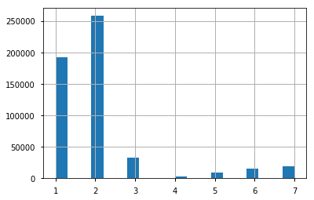

```python
##Class Distribution in Training Data

traincsv['Cover_Type'].hist(bins=20).plot()
```

We can observe that our data in inbalanced , there are many methods that help to deal with this issue like resampling or weighting , but for instance , we will not fo through this problem

## 3- Trying first model

Let's try a first model without processing the data .The most intuitive and informative model that comes to our mind is decision tree .

First , we need to randomly choose 20% of the training data and set it aside for our evaluation.

```python
# Import train_test_split
from sklearn.model_selection import train_test_split

#classes  = traincsv['Cover_Type']
# Split the 'features' and 'income' data into training and testing sets
#75/25 Split
#traincsv=traincsv.dropna()
X_train, X_test, y_train, y_test = train_test_split(traincsv.ix[:,:-1].values, traincsv.ix[:,-1:].values.ravel(),test_size = 0.2, random_state = 0)

# Show the results of the split
print("Training set has {} samples.".format(X_train.shape))
print("Testing set has {} samples.".format(X_test.shape))
```

```
Training set has (422976, 54) samples.
Testing set has (105744, 54) samples.
```

Let's train the model and see the results

```python
#
# derive a decision tree classifier for our data and plot its first two levels (below the root).
#  The purpose is to determine illustrate the utility of the graphviz visualization.
#
import pydotplus
from sklearn import tree

features = traincsv.copy().drop(['Cover_Type'],axis=1)
clf = tree.DecisionTreeClassifier()
clf = clf.fit(X_train, y_train)
dot_data = tree.export_graphviz(decision_tree=clf, filled=True, rounded=True,
                                feature_names=features.columns, class_names=("1","2","3","4","5","6","7"),
                                max_depth=2, special_characters=True, out_file='dot.dot')
print("The test-score de of Decision trees is %.2f" %clf.score(X_test,y_test))
```

```
The test-score de of Decision trees is 0.90
```

```python
#Obtain Baseline Performance of Many Classifiers

from time import time
from sklearn.metrics import fbeta_score, accuracy_score
from sklearn.linear_model import LogisticRegression, SGDClassifier
from sklearn.tree         import DecisionTreeClassifier
from sklearn.ensemble     import BaggingClassifier, AdaBoostClassifier, GradientBoostingClassifier,\
                                 RandomForestClassifier

for clf in [DecisionTreeClassifier(), LogisticRegression(), SGDClassifier(),  BaggingClassifier(),
           AdaBoostClassifier()]:
    start_time  = time()
    learner     = clf.fit(X_train, y_train)
    predictions = clf.predict(X_test)
    end_time    = time()
    print("%s: %2.3f%% %0.1f secs." % (clf.__class__.__name__, \
                                       100.0*accuracy_score(y_test, predictions), \
                                      (end_time-start_time)))
```

```
DecisionTreeClassifier: 90.427% 8.2 secs.
LogisticRegression: 70.904% 125.4 secs.
SGDClassifier: 49.189% 5.3 secs.
BaggingClassifier: 93.731% 63.7 secs.
AdaBoostClassifier: 57.383% 39.8 secs.
```

```python
rf_initial=RandomForestClassifier(n_estimators=10, bootstrap=True, oob_score=True)
rf_initial.fit(X_train, y_train)
```

```
RandomForestClassifier(bootstrap=True, class_weight=None, criterion='gini',
            max_depth=None, max_features='auto', max_leaf_nodes=None,
            min_impurity_decrease=0.0, min_impurity_split=None,
            min_samples_leaf=1, min_samples_split=2,
            min_weight_fraction_leaf=0.0, n_estimators=10, n_jobs=1,
            oob_score=True, random_state=None, verbose=0, warm_start=False)
```

Let's define a function that displays the importance of variables :

```python
def importances(estimator, col_array, title):
    importances = estimator.feature_importances_
    indices = np.argsort(importances)[::-1]
    print ("%s Top 20 Important Features\n" %title)
    for f in range(20):
        print("%d. %s (%f)" % (f + 1, col_array.columns[indices[f]], importances[indices[f]]))
    print ("\nMean Feature Importance %.6f" %np.mean(importances))
    indices=indices[:10]
    plt.figure()
    plt.title(title+" Top 10 Feature importances")
    plt.bar(range(10), importances[indices], color="gr", align="center")
    plt.xticks(range(10), col_array.columns[indices], fontsize=14, rotation=90)
    plt.xlim([-1, 10])
    plt.show()
```

```
Cover Type (Initial RF) Top 20 Important Features

1. Elevation (0.243735)
2. Horizontal_Distance_To_Roadways (0.108431)
3. Horizontal_Distance_To_Fire_Points (0.103561)
4. Horizontal_Distance_To_Hydrology (0.064395)
5. Vertical_Distance_To_Hydrology (0.058682)
6. Aspect (0.049262)
7. Hillshade_Noon (0.045639)
8. Wilderness_Area4 (0.043799)
9. Hillshade_3pm (0.043596)
10. Hillshade_9am (0.043082)
11. Slope (0.034666)
12. Soil_Type22 (0.016067)
13. Soil_Type4 (0.012049)
14. Soil_Type23 (0.011579)
15. Wilderness_Area3 (0.010525)
16. Soil_Type39 (0.010429)
17. Wilderness_Area1 (0.009489)
18. Soil_Type2 (0.008987)
19. Soil_Type10 (0.008850)
20. Soil_Type38 (0.008766)

Mean Feature Importance 0.018519
```

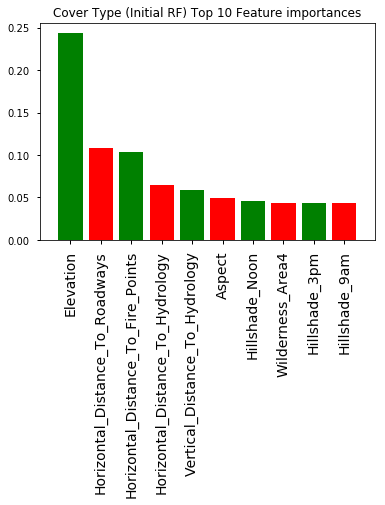

```python
#Call the method we just created to display the feature importances
importances(rf_initial, traincsv, "Cover Type (Initial RF)")
```

## 4. Visualizing and preprocessing the data

We'll continue to refer back to these importances as we move through this exercise. Data Exploration

We'll now begin to examine the data through a series of visualizations. Let's start by looking at histograms of the features to find any missing values.

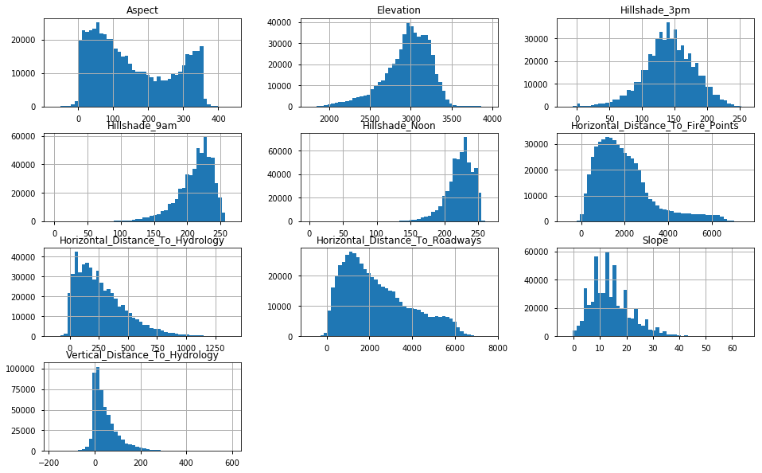

```python
traincsv.ix[:,:10].hist(figsize=(16,10), bins=50)
plt.show()
```

Looks like there're some missing values for Hillshade at 3 PM. If there was shade at 9 AM, I'd expect little shade at 3 PM but 0 doesn't sit right. We'll explore this further down the line, since Hillshade 3 PM is in the Top 10.

### Linearity of Cover Types

Let's try to explore the relahionship between Elevation and other variables that are naturally connected to it.

```python
#Let's add Cover Type to smaller_frame so we can color code.
smaller_frame['Cover_Type']=traincsv.Cover_Type
```

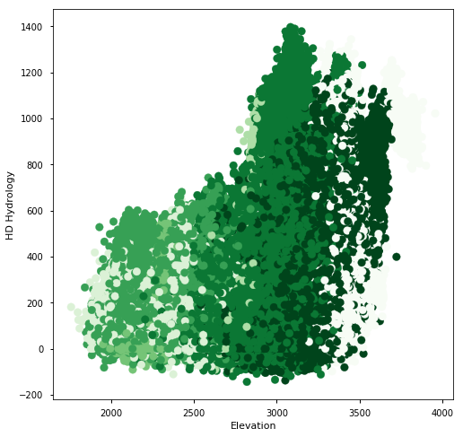

```python
#Elevation vs HD Hydrology
plt.figure(figsize=(8,8))
plt.scatter(smaller_frame.Elevation, smaller_frame.HD_Hydrology, c=smaller_frame.Cover_Type, s=75, cmap=plt.cm.Greens_r)
plt.xlabel("Elevation")
plt.ylabel("HD Hydrology")
plt.show()
```

So if we created a new feature that reduced the Elevation values slightly in relation to HD Hydrology, we probably could get more similar labels to align with each other. Let's find out.

### Filling up missing values

Let's now turn our attention to Hillshade 3 PM where we found some missing values (zeros). We will plot an SPLOM to understand how the hillshade features are related.

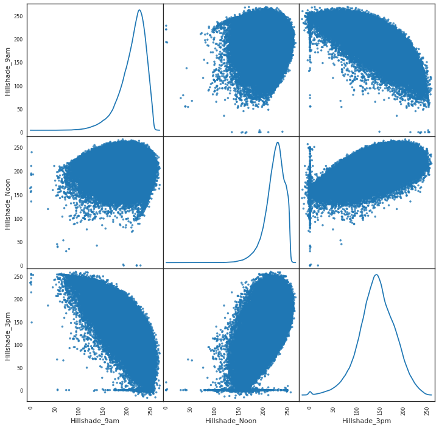

```python
with seaborn.axes_style('white'):
    smaller_frame = traincsv[['Hillshade_9am', 'Hillshade_Noon','Hillshade_3pm']]
    scatter_matrix(smaller_frame, alpha=0.8, figsize=(12, 12), diagonal="kde")
plt.show()
```

OK that makes sense. Looking at the relationship between hillshade 3 PM and 9 AM, they've clear negative correlation while 3 PM and noon have positive correlation. But are there values that are 0's?

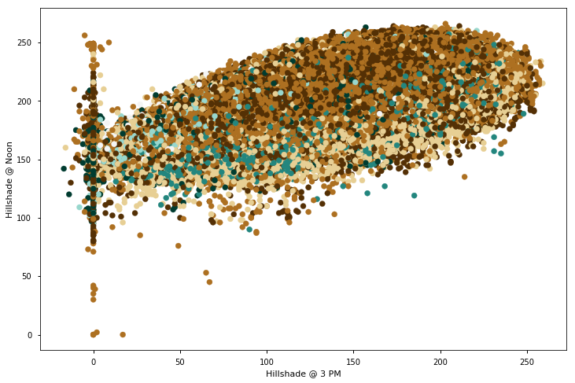

```python
plt.figure(figsize=(12,8))
plt.scatter(traincsv.Hillshade_3pm,traincsv.Hillshade_Noon, c=traincsv.Cover_Type, s=50, cmap=plt.cm.BrBG)
plt.xlabel('Hillshade @ 3 PM')
plt.ylabel('Hillshade @ Noon')
plt.show()
```

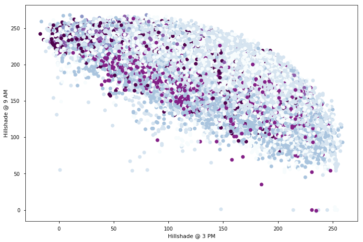

```python
plt.figure(figsize=(12,8))
plt.scatter(traincsv.Hillshade_3pm,traincsv.Hillshade_9am, c=traincsv.Cover_Type, s=50, cmap=plt.cm.BuPu)
plt.xlabel('Hillshade @ 3 PM')
plt.ylabel('Hillshade @ 9 AM')
plt.show()
```

There're clearly hillshade values at 3 PM that are zeroes. Before we fill these up, just for kickers let's plot the relationship between hillshade at 9 AM and Noon where 3 PM hillshade is 0. There must be some trend there that we can spot.

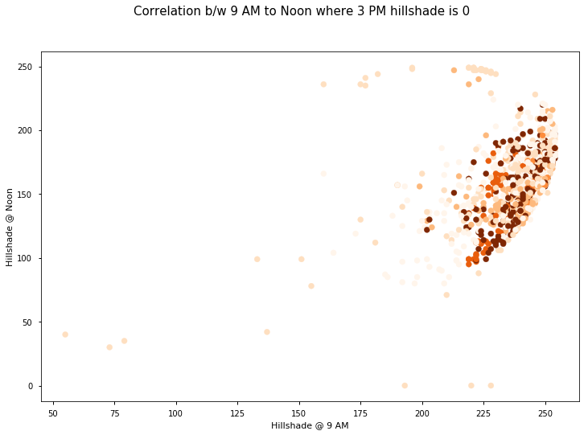

```python
smaller_frame=traincsv[traincsv.Hillshade_3pm==0]
plt.figure(figsize=(12,8))
plt.scatter(smaller_frame.Hillshade_9am,smaller_frame.Hillshade_Noon, c=smaller_frame.Cover_Type, s=50, cmap=plt.cm.Oranges)
plt.suptitle('Correlation b/w 9 AM to Noon where 3 PM hillshade is 0', fontsize=15)
plt.xlabel('Hillshade @ 9 AM')
plt.ylabel('Hillshade @ Noon')
plt.show()
```

As expected, we see a clear positive correlation in the graph. Perhaps, we could fit a regressor to the traincsv dataset to predict the missing 3 PM hillshade values.

OK, let's now extract the columns we've chosen and fit a regression model to this dataset. Note that any changes we make should also be made to the Test.csv dataset so we can generate the final predictions. Let's play nice and only train on all values from train.csv, then use it to predict missing values in both datasets.

##### Reorder Columns

I like reordering columns so that the label we're predicting (or continuous value in this case) is the last column. Let's however make a copy this time since we don't want to be changing the original traincsv dataset.

Hillshade 3 PM is the 9th column and we want to move it to the end.

```python
#Make a copy and Reorder train.csv columns
temp=traincsv.copy()
print( "The number of missing valueson Hillshade_3pm to predict is %s" % len(temp.Hillshade_3pm.loc[temp.Hillshade_3pm==0 ]))
cols=temp.columns.tolist()
cols=cols[:8]+cols[9:]+[cols[8]]
temp=temp[cols]
#Delete the Forest Cover Type column. We can't train on this since it doesn't exist in the test.csv file
del temp['Cover_Type']
```

```
The number of missing valueson Hillshade_3pm to predict is 1004
```

```python
#Split the train.csv file into train (available values) and missing values based on hillshade 3 PM.
X= temp[temp.Hillshade_3pm!=0].values[:,:-1]
y=temp[temp.Hillshade_3pm!=0].values[:,-1:].ravel()
X_traincsv_missing=  temp[temp.Hillshade_3pm==0].values[:,:-1]
y_traincsv_missing= temp[temp.Hillshade_3pm==0].values[:,-1:].ravel()
#Let's very quickly do a train/cv split so we can see how the model will generalize. Note that we're calling this cv since
#we're not going to be doing exhaustive cross-validation. We'll test performance using the cv set and predict on test. I am
#calling this cv so as to not confuse with terminology.
X_train,X_test,y_train,y_test=train_test_split(X,y)
```

```python
#Fit a Regression model to this dataset.
linmodel= LinearRegression()
linmodel.fit(X_train,y_train)
```

```
LinearRegression(copy_X=True, fit_intercept=True, n_jobs=1, normalize=False)
```

Let's quickly check how well the model fit to the dataset and if there's any overfitting. Note that we're not doing any extensive cross-validation in this case. We'll save that for the actual forest cover type prediction

```python
print ('Training R-squared value: %.2f' %linmodel.score(X_train, y_train))
print ('Test R-squared value: %.2f' %linmodel.score(X_test, y_test) )
```

```
Training R-squared value: 0.99
Test R-squared value: 0.99
```

```python
temp.Hillshade_3pm.loc[temp.Hillshade_3pm==0]=linmodel.predict(X_traincsv_missing)
traincsv.Hillshade_3pm=temp.Hillshade_3pm
```

```python
#Make a copy and Reorder test.csv columns
temp=testcsv.copy()
cols=temp.columns.tolist()
cols=cols[:8]+cols[9:]+[cols[8]]
temp=temp[cols] #Extract missing rows from test.csv then predict and fill in the blanks.
X_testcsv_missing= temp[temp.Hillshade_3pm==0].values[:,:-1]
temp.Hillshade_3pm.loc[temp.Hillshade_3pm==0]=linmodel.predict(X_testcsv_missing)
testcsv.Hillshade_3pm=temp.Hillshade_3pm
```

## 5. Feature Engineering

After processing the missing values , let's try to create some new features :

The first idea that come to mind is to create a slope to water features (hydrology) since we've been already provided vertical and horizontal distances.

##### Slope distance and Percent to Hydrology

Let's calculate slope distance

```python
#Create two new columns named Slope hydrology and Slope hydrology percent and remove any infinite values that may result

traincsv['slope_hyd'] = np.sqrt(traincsv.Vertical_Distance_To_Hydrology**2 + traincsv.Horizontal_Distance_To_Hydrology**2)
traincsv.slope_hyd=traincsv.slope_hyd.map(lambda x: 0 if np.isinf(x) else x)
```

```python
#Apply changes to test.csv as well
testcsv['slope_hyd'] = np.sqrt(testcsv.Vertical_Distance_To_Hydrology**2 +testcsv.Horizontal_Distance_To_Hydrology**2)
testcsv.slope_hyd=testcsv.slope_hyd.map(lambda x: 0 if np.isinf(x) else x)
```

#### Elevation adjusted by distance to Hydrology and Roadways

As we saw earlier , the elevation is highly important in the RandomForest model . let's try to adjust this variable by horizontal/vertical distances to Hydrology, Fire and Roadways.

```python
#Elevation adjusted by Horizontal distance to Hyrdrology
traincsv['Elev_to_HD_Hyd']=traincsv.Elevation - 0.5 * traincsv.Horizontal_Distance_To_Hydrology
testcsv['Elev_to_HD_Hyd']=testcsv.Elevation - 0.5* testcsv.Horizontal_Distance_To_Hydrology

#Elevation adjusted by Horizontal distance to Roadways
traincsv['Elev_to_HD_Road']=traincsv.Elevation - 0.5 * traincsv.Horizontal_Distance_To_Roadways
testcsv['Elev_to_HD_Road']=testcsv.Elevation - 0.5 * testcsv.Horizontal_Distance_To_Roadways

#Elevation adjusted by Vertical distance to Roadways
traincsv['Elev_to_VD_Hyd']=traincsv.Elevation - traincsv.Vertical_Distance_To_Hydrology
testcsv['Elev_to_VD_Hyd']=testcsv.Elevation - testcsv.Vertical_Distance_To_Hydrology
```

#### Distance to Amenities

We had earlier seen that the distances to amenities like Water, Fire and Roadways played a key role in determining cover type. Let's create some more features based on these horizontal distances.

```python
#Mean distance to Amenities
traincsv['Mean_Amenities']=(traincsv.Horizontal_Distance_To_Fire_Points + traincsv.Horizontal_Distance_To_Hydrology + traincsv.Horizontal_Distance_To_Roadways) / 3
testcsv['Mean_Amenities']=(testcsv.Horizontal_Distance_To_Fire_Points + testcsv.Horizontal_Distance_To_Hydrology + testcsv.Horizontal_Distance_To_Roadways) / 3
#Mean Distance to Fire and Water
traincsv['Mean_Fire_Hyd']=(traincsv.Horizontal_Distance_To_Fire_Points + traincsv.Horizontal_Distance_To_Hydrology) / 2
testcsv['Mean_Fire_Hyd']=(testcsv.Horizontal_Distance_To_Fire_Points + testcsv.Horizontal_Distance_To_Hydrology) / 2
```

Now let's move forward and see how the new features help to explain the cover type

#### Reorder columns

We need to reorder the columns and put the Cover Type in the last column.

```python
#Reorder train.csv columns
cols=traincsv.columns.tolist()
cols=cols[:10]+cols[-6:]+cols[10:-6]
traincsv=traincsv[cols]
```

```python
#Reorder test.csv columns
cols=testcsv.columns.tolist()
cols=cols[:10]+cols[-6:]+cols[10:-6]
testcsv=testcsv[cols]
```

Let's now proceed to train multiple classifiers on this dataset.

#### Normalizing non-categorical variables

```python
from sklearn.preprocessing import StandardScaler
# Taking only non-categorical values
Size = 16
X_temp =traincsv.iloc[:,:Size]
X_test_temp = testcsv.iloc[:,:Size]

X_temp = StandardScaler().fit_transform(X_temp)
X_test_temp = StandardScaler().fit_transform(X_test_temp)
```

```python
## concatenating standardized variables to categorical variables
r,c = traincsv.shape

X_traincsv_std = np.concatenate((X_temp, traincsv.iloc[:,Size:c-1]), axis=1) # to be used for SVM
y_traincsv = traincsv.Cover_Type.values

r,c = testcsv.shape
X_testcsv_std = np.concatenate((X_test_temp, testcsv.iloc[:,Size:c]), axis = 1)
```

## 6. Model Fitting and Cross Validation

We'll now fit our dataset through a series of models and hypertune each through cross-validation. Let's start with everyone's favorite, the Random Forests Classifier.

#### Train Test Split

Before we do anything else, let's split the traincsv into training and test sets. Note that test from this point on refers to the test split that we're creating now (from traincsv). We will NOT be using the testcsv dataset until we're ready to make predictions

```python
X_train, X_test, y_train, y_test = train_test_split(X_traincsv_std , y_traincsv, test_size = 0.2, random_state = 0)
print(X_train.shape, X_test.shape, y_train.shape, y_test.shape)
```

```
(422976, 60) (105744, 60) (422976,) (105744,)
```

#### Cross Validation Generator

All right let's do this the right way.

Luckily scikit-learn has builit-in packages that can help with this. We'll use a crossvalidation generator that can train the model by tuning the parameters based on a cross-validation subset (cv) that is picked from within the training set. A different cv subset will be picked for each iteration, we control the number of iterations. Then we will use these cv/train splits and run a gridsearch function that will evaluate the model with each split and tune parameters to give us the best parameter that gives the optimal result.

Let's define this as a function so we can call on it as many times as we please later on.

```python
def CrossValidate(estimator, param_grid, n_jobs): #Choose cross-validation generator - let's choose ShuffleSplit which randomly shuffles and selects Train and CV sets
    #for each iteration. There are other methods like the KFold split. c
    cv = ShuffleSplit(X_train.shape[0], n_iter=3, test_size=0.2)
    classifier = GridSearchCV(estimator=estimator, cv=cv, param_grid=param_grid, n_jobs=n_jobs, scoring='accuracy')
    #Also note that we're feeding multiple neighbors to the GridSearch to try out.
    #We'll now fit the training dataset to this classifier
    classifier.fit(X_train, y_train) #Let's look at the best estimator that was found by GridSearchCV
    print ("Best Estimator learned through GridSearch")
    print (classifier.best_estimator_)
    return cv, classifier.best_estimator_
```

#### Learning Curves

Let's define a a function that plots the learning curve of an estimator ,it will allow to easily visualize how the performance of the model vary acccording to sample size . It helps also to detect if an overfitting occurs . We'll once again define this as a function so we can call on it multiple times.

```python
print(__doc__)

import numpy as np
import matplotlib.pyplot as plt
from sklearn import cross_validation
from sklearn.naive_bayes import GaussianNB
from sklearn.datasets import load_digits
from sklearn.learning_curve import learning_curve


def plot_learning_curve(estimator, title, X, y, ylim=None, cv=None,n_jobs=4, train_sizes=np.linspace(.1, 1.0, 5)):
    """
    Generate a simple plot of the test and traning learning curve.

    Parameters
    ----------
    estimator : object type that implements the "fit" and "predict" methods
        An object of that type which is cloned for each validation.

    title : string
        Title for the chart.

    X : array-like, shape (n_samples, n_features)
        Training vector, where n_samples is the number of samples and
        n_features is the number of features.

    y : array-like, shape (n_samples) or (n_samples, n_features), optional
        Target relative to X for classification or regression;
        None for unsupervised learning.

    ylim : tuple, shape (ymin, ymax), optional
        Defines minimum and maximum yvalues plotted.

    cv : integer, cross-validation generator, optional
        If an integer is passed, it is the number of folds (defaults to 3).
        Specific cross-validation objects can be passed, see
        sklearn.cross_validation module for the list of possible objects

    n_jobs : integer, optional
        Number of jobs to run in parallel (default 1).
    """
    plt.figure()
    plt.title(title)
    if ylim is not None:
        plt.ylim(*ylim)
    plt.xlabel("Training examples")
    plt.ylabel("Score")
    train_sizes, train_scores, test_scores = learning_curve(
        estimator, X, y, cv=cv, n_jobs=n_jobs, train_sizes=train_sizes)
    train_scores_mean = np.mean(train_scores, axis=1)
    train_scores_std = np.std(train_scores, axis=1)
    test_scores_mean = np.mean(test_scores, axis=1)
    test_scores_std = np.std(test_scores, axis=1)
    plt.grid()

    plt.fill_between(train_sizes, train_scores_mean - train_scores_std,
                     train_scores_mean + train_scores_std, alpha=0.1,
                     color="r")
    plt.fill_between(train_sizes, test_scores_mean - test_scores_std,
                     test_scores_mean + test_scores_std, alpha=0.1, color="g")
    plt.plot(train_sizes, train_scores_mean, 'o-', color="r",
             label="Training score")
    plt.plot(train_sizes, test_scores_mean, 'o-', color="g",
             label="Cross-validation score")

    plt.legend(loc="best")
    return plt
```

```
Automatically created module for IPython interactive environment
```

```python
###SELECT INTERRUPT IN THE MENU AND PRESS INTERRUPT KERNEL IF YOU NEEDD TO STOP EXECUTION
estimator=RandomForestClassifier(bootstrap=True, oob_score=True)

param_grid={'n_estimators': [50,100], #[100, 1000, 5000],
            'max_depth': [15,20,30],
           }
n_jobs=2
#Let's fit RF to the training dataset by calling the function we just created.
cv,best_estimator=CrossValidate(estimator, param_grid, n_jobs)
```

```
Best Estimator learned through GridSearch
RandomForestClassifier(bootstrap=True, class_weight=None, criterion='gini',
            max_depth=30, max_features='auto', max_leaf_nodes=None,
            min_impurity_decrease=0.0, min_impurity_split=None,
            min_samples_leaf=1, min_samples_split=2,
            min_weight_fraction_leaf=0.0, n_estimators=100, n_jobs=1,
            oob_score=True, random_state=None, verbose=0, warm_start=False)
```

```python
#OK great, so we got back the best estimator parameters as follows:
print("Best Estimator Parameters")
print("---------------------------")
print ("n_estimators: %d" %best_estimator.n_estimators)
print ("max_depth: %d" %best_estimator.max_depth)
print("")
print ("Training Score(F1): %.2f" %best_estimator.score(X_train,y_train))
```

```
Best Estimator Parameters
---------------------------
n_estimators: 100
max_depth: 30

Training Score(F1): 1.00
```

```
Cover Type - Random Forests try I Top 20 Important Features

1. Elev_to_VD_Hyd (0.126219)
2. Elevation (0.112230)
3. Elev_to_HD_Hyd (0.103218)
4. Mean_Amenities (0.063798)
5. Elev_to_HD_Road (0.060130)
6. Horizontal_Distance_To_Roadways (0.056069)
7. Horizontal_Distance_To_Fire_Points (0.053244)
8. Mean_Fire_Hyd (0.053093)
9. Aspect (0.032162)
10. Vertical_Distance_To_Hydrology (0.031377)
11. Hillshade_Noon (0.031270)
12. slope_hyd (0.029909)
13. Hillshade_9am (0.028284)
14. Horizontal_Distance_To_Hydrology (0.027434)
15. Hillshade_3pm (0.027185)
16. Slope (0.020725)
17. Wilderness_Area4 (0.018895)
18. Wilderness_Area1 (0.010719)
19. Wilderness_Area3 (0.010390)
20. Soil_Type22 (0.009886)

Mean Feature Importance 0.016667
```

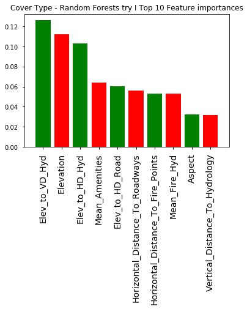

```python
#Calling fit on the estimator so we can look at feature_importances.
importances(best_estimator, traincsv, "Cover Type - Random Forests try I")
```

So looks like we've done a pretty good job manufacturing features there. Almost all of the features we engineered have made it to the Top 10 and have kind of eaten into the importance score of Elevation.

Great, let's now plot the learning curve to see if there's any overfitting (or underfitting).

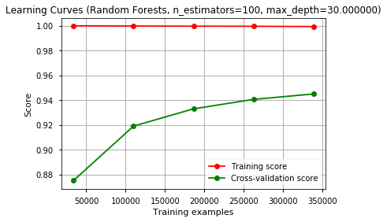

```python
title = "Learning Curves (Random Forests, n_estimators=%d, max_depth=%.6f)" %(best_estimator.n_estimators, \
                                                                              best_estimator.max_depth)
plot_learning_curve(best_estimator, title, X_train, y_train, cv=cv, n_jobs=2)
plt.show()
```

```python
#Run predictions on the Test set
y_pred=best_estimator.predict(X_test)
print ("Training Score: %.2f" %best_estimator.score(X_train,y_train) )
print ("Test Score: %.2f" %best_estimator.score(X_test,y_test))
print ("Classification Report - Test" )
print (metrics.classification_report(y_test, y_pred) )
```

```
Training Score: 1.00
Test Score: 0.95
Classification Report - Test
             precision    recall  f1-score   support

          1       0.95      0.94      0.95     38338
          2       0.95      0.97      0.96     51765
          3       0.94      0.96      0.95      6566
          4       0.93      0.82      0.87       515
          5       0.93      0.76      0.84      1702
          6       0.92      0.89      0.91      3174
          7       0.96      0.94      0.95      3684

avg / total       0.95      0.95      0.95    105744
```

That's interesting to see. The two Cover Types our model is relatively not predicting well are labels 4 and 5 .The rest have atleast a 91% probability. Overally we have about 95% success rate with the test set.

As we can see in the learning curve , the performance is perfect on the training set but not so great on cross-validation. Let's try changing an ensemble learning approach in order to avoid this overfitting .

#### An ensembling learning approach

```python
from sklearn.model_selection import GridSearchCV
from sklearn.linear_model import LogisticRegression
from sklearn.naive_bayes import GaussianNB
from sklearn.ensemble import RandomForestClassifier

from sklearn.ensemble import RandomForestClassifier
from sklearn.ensemble import ExtraTreesClassifier,VotingClassifier
from sklearn.tree import DecisionTreeClassifier

from sklearn.neighbors import KNeighborsClassifier

optimal_k=10

xtree = ExtraTreesClassifier(n_estimators=50, max_depth=None, min_samples_split=2, random_state=0)
kNN = KNeighborsClassifier(n_neighbors=optimal_k)

eclf = VotingClassifier(estimators=[('best_estimator',best_estimator),('xtree',xtree),('KNN',kNN)], voting='soft')

eclf.fit(X_train, y_train)
```

```
VotingClassifier(estimators=[('best_estimator', RandomForestClassifier(bootstrap=True, class_weight=None, criterion='gini',
            max_depth=30, max_features='auto', max_leaf_nodes=None,
            min_impurity_decrease=0.0, min_impurity_split=None,
            min_samples_leaf=1, min_samples_split=2,
        ...wski',
           metric_params=None, n_jobs=1, n_neighbors=10, p=2,
           weights='uniform'))],
         flatten_transform=None, n_jobs=1, voting='soft', weights=None)
```

#### Submit predictions to kaggle

```python
#Run predictions on the Test set
y_pred=eclf.predict(X_test)
print ("Training Score: %.2f" %eclf.score(X_train,y_train) )
print ("Test Score: %.2f" %eclf.score(X_test,y_test))
print ("Classification Report - Test" )
print (metrics.classification_report(y_test, y_pred) )
```

```
Training Score: 1.00
Test Score: 0.95
Classification Report - Test
             precision    recall  f1-score   support

          1       0.96      0.95      0.95     38338
          2       0.95      0.97      0.96     51765
          3       0.94      0.96      0.95      6566
          4       0.93      0.80      0.86       515
          5       0.93      0.80      0.86      1702
          6       0.92      0.90      0.91      3174
          7       0.96      0.95      0.96      3684

avg / total       0.95      0.95      0.95    105744
```

The use of an ensemble learning approach has enhanced the f1-score on category 5 ,let's submit our predictions to kaggle and see the results.

```python
#Make a copy of the test.csv file
temp=pd.DataFrame(X_testcsv_std).copy()
temp.index=testcsv.index # make sure of the index

#Run Predictions on test.csv
temp['Cover_Type']=eclf.predict(temp)

#Create Submissions csv file
temp=temp['Cover_Type']
temp.to_csv('kaggle_submission_final.csv', header=True)
print("Predictions exported succesfully")
```

```
Predictions exported succesfully
```

The final ranking and the score I obtained after submission to Kaggle :

**Rank** : 12 | **Team Name** :Mohamed Dhaoui | **Score** : 0.95765 |